# Statistical Learning B: Final Project

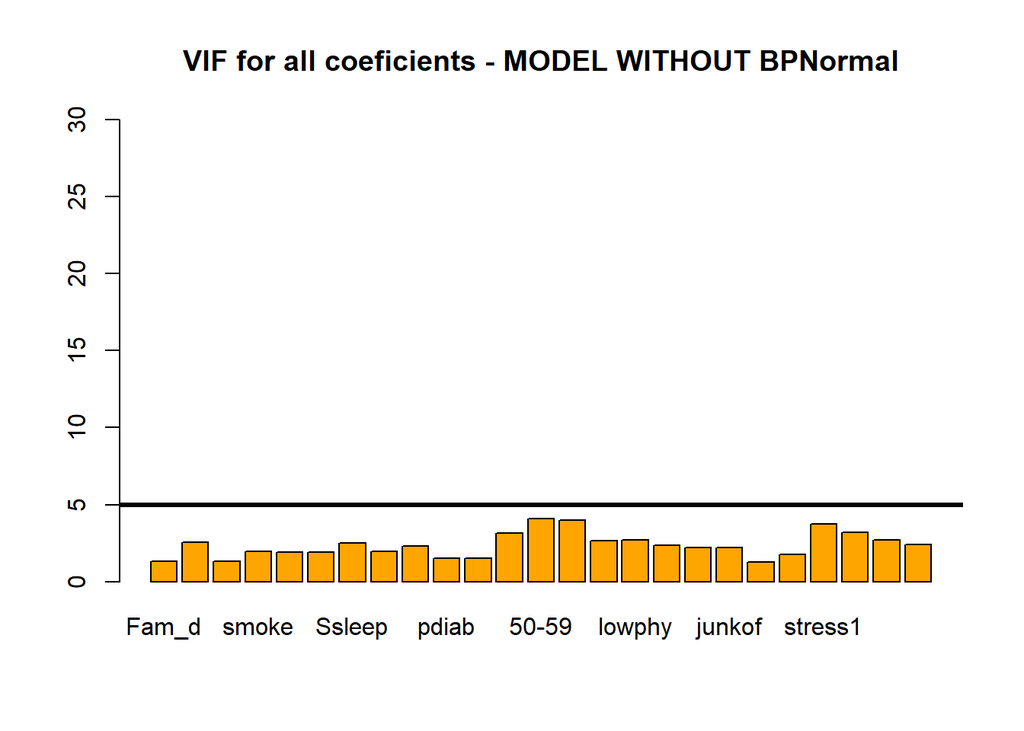

```r
# Create bar chart to display VIF values

barplot(all_vif1, main = "VIF for all coeficients - MODEL WITHOUT BPNormal", horiz = FALSE, col = "orange", names.arg = c('Fam_d','h_bp','BMI','smoke','alc','sleep','Ssleep','regmed','preg','pdiab','ur','40-49','50-59','60ab','male','lowphy','midphy','highphy','junkof','junkvof','junkal','stress1','stress2','stress3','highbp'), ylim = c(0,30))

# Add a line to highlight severe correlation when VIF > 5

abline(h = 5, lwd = 3, lty = 1)
```

Now, we observe this new model’s performance through VIF analysis, sensitivity and precision measures.

```r
#Prediction and confusion matrix for model identified through VIF analysis

log_prob_VIFmod  <- predict(log_reg1, test.data, type = 'response')
logistic_pred_VIFmod  <- rep(0, dim(test.data)[1])
logistic_pred_VIFmod [log_prob_VIFmod>0.5] <- 1
vif_confusion <- confusionMatrix(data=as.factor(logistic_pred_VIFmod), reference = as.factor(test.data$Diabetic), positive = '1')
vif_confusion
```

```
## Confusion Matrix and Statistics
##
##           Reference
## Prediction   0   1
##          0 119  13
##          1   4  42
##
##                Accuracy : 0.9045
##                  95% CI : (0.8515, 0.9434)
##     No Information Rate : 0.691
##     P-Value [Acc > NIR] : 9.189e-12
##
##                   Kappa : 0.7658
##
##  Mcnemar's Test P-Value : 0.05235
##
##             Sensitivity : 0.7636
##             Specificity : 0.9675
##          Pos Pred Value : 0.9130
##          Neg Pred Value : 0.9015
##              Prevalence : 0.3090
##          Detection Rate : 0.2360
##    Detection Prevalence : 0.2584
##       Balanced Accuracy : 0.8656
##
##        'Positive' Class : 1
##
```

Now, we check for the best treshold of P in the case of the new model without BPNormal (log_reg1).

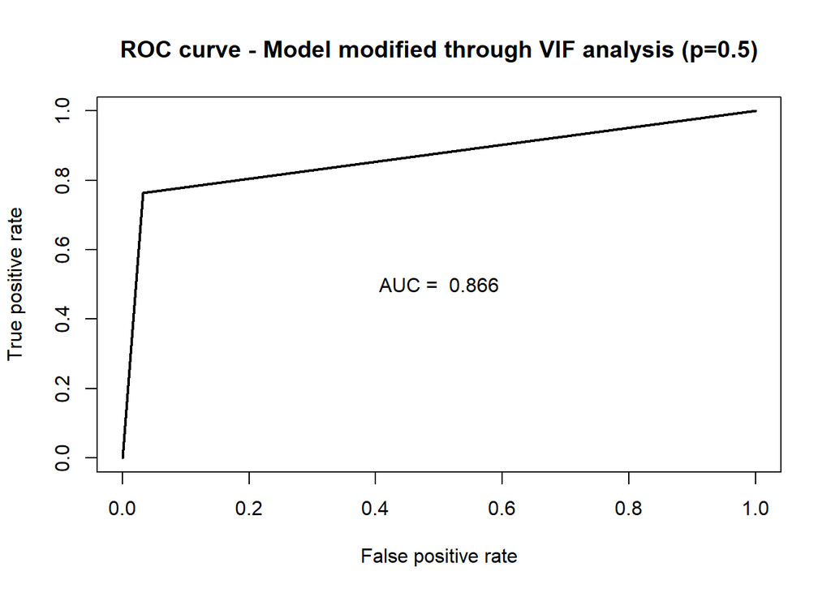

```r
VIFmod_prediction <- prediction(logistic_pred_VIFmod, test.data$Diabetic)

roc_curve_VIFmod <- performance(VIFmod_prediction, measure="tpr", x.measure = "fpr" )

auc <- performance(VIFmod_prediction, measure="auc")

auc <- auc@y.values[[1]]

auc <- as.character(round(auc, 3))

plot(roc_curve_VIFmod, main="ROC curve - Model modified through VIF analysis (p=0.5)", lwd=2)

full_auc = paste("AUC = ", auc)

text(0.5, 0.5, full_auc)
```

```r
# (Testing) error rate among diabetic subjects with p=0.5

table(logistic_pred_VIFmod, test.data$Diabetic)
```

```
##
## logistic_pred_VIFmod   0   1
##                    0 119  13
##                    1   4  42
```

```r
FN = table(logistic_pred_VIFmod, test.data$Diabetic)[1,2]
TP = table(logistic_pred_VIFmod, test.data$Diabetic)[2,2]
err_05_VIF = FN/(FN+TP)
err_05_VIF #0.2363636
```

```
## [1] 0.2363636
```

```r
#Prediction and confusion matrix for full model (p=0.1)

dim(test.data)
```

```
## [1] 178  27
```

```r
log_prob <- predict(log_reg1, test.data, type = 'response')
logistic_pred_VIFmod_01 <- rep(0, dim(test.data)[1])
logistic_pred_VIFmod_01[log_prob>0.1] <- 1
VIF_confusion_01 <- confusionMatrix(data=as.factor(logistic_pred_VIFmod_01), reference = as.factor(test.data$Diabetic), positive = '1')
VIF_confusion_01
```

```
## Confusion Matrix and Statistics
##
##           Reference
## Prediction  0  1
##          0 98  2
##          1 25 53
##
##                Accuracy : 0.8483
##                  95% CI : (0.787, 0.8976)
##     No Information Rate : 0.691
##     P-Value [Acc > NIR] : 1.060e-06
##
##                   Kappa : 0.6816
##
##  Mcnemar's Test P-Value : 2.297e-05
##
##             Sensitivity : 0.9636
##             Specificity : 0.7967
##          Pos Pred Value : 0.6795
##          Neg Pred Value : 0.9800
##              Prevalence : 0.3090
##          Detection Rate : 0.2978
##    Detection Prevalence : 0.4382
##       Balanced Accuracy : 0.8802
##
##        'Positive' Class : 1
##
```

```r
# (Testing) error rate among diabetic subjects with p=0.1

table(logistic_pred_VIFmod_01, test.data$Diabetic)
```

```
##
## logistic_pred_VIFmod_01  0  1
##                       0 98  2
##                       1 25 53
```

```r
FN = table(logistic_pred_VIFmod_01, test.data$Diabetic)[1,2]
TP = table(logistic_pred_VIFmod_01, test.data$Diabetic)[2,2]
err_01_VIF = FN/(FN+TP)
err_01_VIF #0.03636364
```

```
## [1] 0.03636364
```

Here, we plot the ROC curve for the model with p=0.1, for comparison.

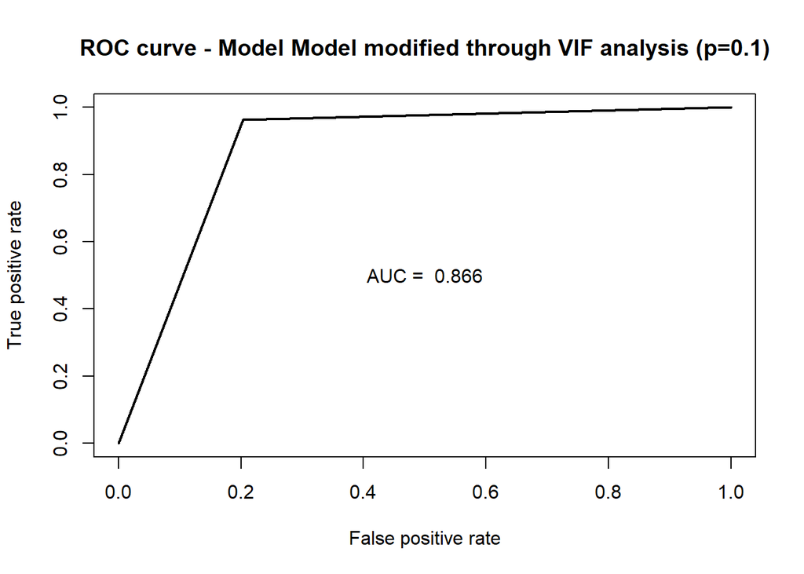

```r
VIF_prediction_01 <- prediction(logistic_pred_VIFmod_01, test.data$Diabetic)

roc_curve_VIF_01 <- performance(VIF_prediction_01, measure="tpr", x.measure = "fpr" )

auc <- performance(VIF_prediction_01, measure="auc")

auc <- auc@y.values[[1]]

auc <- round(auc, 3)

plot(roc_curve_VIF_01, main="ROC curve - Model Model modified through VIF analysis (p=0.1)", lwd=2)

auc_best_VIFmod = paste("AUC = ", auc)

text(0.5, 0.5, full_auc)
```

### 2.3.2 Stepwise logistic regression

Even after observing the VIFs and dropping BPNormal, we still have 25 explanatory variables in our model, many of which are not significant. In order to explore the possibility of dropping other variables, we perform an automatic stepwise selection procedure.

```r
#Stepwise logistic

model <- glm(Diabetic ~., data = train.data, family = binomial)
summary(model)
```

```
##
## Call:
## glm(formula = Diabetic ~ ., family = binomial, data = train.data)
##
## Deviance Residuals:
##     Min       1Q   Median       3Q      Max
## -2.7894  -0.3327  -0.1065   0.2168   3.4310
##
## Coefficients:
##                  Estimate Std. Error z value Pr(>|z|)
## (Intercept)     -20.52157  802.58895  -0.026 0.979601
## Family_Diabetes   1.02378    0.29558   3.464 0.000533 ***
## highBP           -0.49085    0.43928  -1.117 0.263825
## BMI               0.14818    0.29755   0.498 0.618496
## Smoking           1.45314    0.63122   2.302 0.021328 *
## Alcohol          -0.49960    0.44298  -1.128 0.259399
## Sleep            -0.03563    0.13394  -0.266 0.790245
## SoundSleep        0.22282    0.10783   2.066 0.038800 *
## RegularMedicine   2.84175    0.36656   7.753 9.00e-15 ***
## Pregnancies       0.23049    0.19069   1.209 0.226782
## Pdiabetes         5.16589    1.24142   4.161 3.16e-05 ***
## UriationFreq      0.14506    0.33756   0.430 0.667403
## Age40_49          2.29328    0.53196   4.311 1.62e-05 ***
## Age50_59          3.02819    0.56663   5.344 9.08e-08 ***
## Age_60            4.24231    0.61308   6.920 4.53e-12 ***
## Gender_M          0.80685    0.42858   1.883 0.059754 .
## PhysLow          -1.26834    0.45601  -2.781 0.005413 **
## PhysMid          -0.04927    0.45999  -0.107 0.914702
## PhysHigh          0.53101    0.45261   1.173 0.240702
## JunkOften         1.55370    0.49697   3.126 0.001770 **
## JunkVeryOften     0.35967    0.67744   0.531 0.595475
## JunkAlways        0.95026    0.94710   1.003 0.315702
## StressSometimes  -0.41828    0.50187  -0.833 0.404591
## StressOften      -0.79422    0.56738  -1.400 0.161575
## StressAlways      0.02921    0.65869   0.044 0.964633
## BPNormal         13.71771  802.58820   0.017 0.986363
## BPHigh           15.18489  802.58827   0.019 0.984905
## ---
## Signif. codes:  0 '***' 0.001 '**' 0.01 '*' 0.05 '.' 0.1 ' ' 1
##
## (Dispersion parameter for binomial family taken to be 1)
##
##     Null deviance: 858.65  on 714  degrees of freedom
## Residual deviance: 386.93  on 688  degrees of freedom
## AIC: 440.93
##
## Number of Fisher Scoring iterations: 16
```

```r
step.model <- model %>% stepAIC(trace = FALSE)
summary(step.model)
```

```
##
## Call:
## glm(formula = Diabetic ~ Family_Diabetes + Smoking + SoundSleep +
##     RegularMedicine + Pregnancies + Pdiabetes + Age40_49 + Age50_59 +
##     Age_60 + Gender_M + PhysLow + PhysHigh + JunkOften + BPHigh,
##     family = binomial, data = train.data)
##
## Deviance Residuals:
##     Min       1Q   Median       3Q      Max
## -2.5017  -0.3590  -0.1205   0.2596   3.4937
##
## Coefficients:
##                 Estimate Std. Error z value Pr(>|z|)
## (Intercept)     -6.91460    0.79343  -8.715  < 2e-16 ***
## Family_Diabetes  1.09488    0.28462   3.847 0.000120 ***
## Smoking          1.43629    0.53076   2.706 0.006808 **
## SoundSleep       0.15679    0.07521   2.085 0.037087 *
## RegularMedicine  2.73542    0.32029   8.541  < 2e-16 ***
## Pregnancies      0.27795    0.16651   1.669 0.095051 .
## Pdiabetes        5.31316    1.16884   4.546 5.48e-06 ***
## Age40_49         2.26351    0.49354   4.586 4.51e-06 ***
## Age50_59         2.86528    0.52140   5.495 3.90e-08 ***
## Age_60           4.23750    0.55878   7.583 3.36e-14 ***
## Gender_M         0.68178    0.37759   1.806 0.070982 .
## PhysLow         -1.27419    0.34759  -3.666 0.000247 ***
## PhysHigh         0.74600    0.35731   2.088 0.036811 *
## JunkOften        1.36503    0.43906   3.109 0.001877 **
## BPHigh           0.98033    0.31343   3.128 0.001762 **
## ---
## Signif. codes:  0 '***' 0.001 '**' 0.01 '*' 0.05 '.' 0.1 ' ' 1
##
## (Dispersion parameter for binomial family taken to be 1)
##
##     Null deviance: 858.65  on 714  degrees of freedom
## Residual deviance: 396.40  on 700  degrees of freedom
## AIC: 426.4
##
## Number of Fisher Scoring iterations: 7
```

Now, we save the model with best AIC.

```r
#Saving the model with best AIC

best.aic <- step.model
summary(best.aic)
```

```
##
## Call:
## glm(formula = Diabetic ~ Family_Diabetes + Smoking + SoundSleep +
##     RegularMedicine + Pregnancies + Pdiabetes + Age40_49 + Age50_59 +
##     Age_60 + Gender_M + PhysLow + PhysHigh + JunkOften + BPHigh,
##     family = binomial, data = train.data)
##
## Deviance Residuals:
##     Min       1Q   Median       3Q      Max
## -2.5017  -0.3590  -0.1205   0.2596   3.4937
##
## Coefficients:
##                 Estimate Std. Error z value Pr(>|z|)
## (Intercept)     -6.91460    0.79343  -8.715  < 2e-16 ***
## Family_Diabetes  1.09488    0.28462   3.847 0.000120 ***
## Smoking          1.43629    0.53076   2.706 0.006808 **
## SoundSleep       0.15679    0.07521   2.085 0.037087 *
## RegularMedicine  2.73542    0.32029   8.541  < 2e-16 ***
## Pregnancies      0.27795    0.16651   1.669 0.095051 .
## Pdiabetes        5.31316    1.16884   4.546 5.48e-06 ***
## Age40_49         2.26351    0.49354   4.586 4.51e-06 ***
## Age50_59         2.86528    0.52140   5.495 3.90e-08 ***
## Age_60           4.23750    0.55878   7.583 3.36e-14 ***
## Gender_M         0.68178    0.37759   1.806 0.070982 .
## PhysLow         -1.27419    0.34759  -3.666 0.000247 ***
## PhysHigh         0.74600    0.35731   2.088 0.036811 *
## JunkOften        1.36503    0.43906   3.109 0.001877 **
## BPHigh           0.98033    0.31343   3.128 0.001762 **
## ---
## Signif. codes:  0 '***' 0.001 '**' 0.01 '*' 0.05 '.' 0.1 ' ' 1
##
## (Dispersion parameter for binomial family taken to be 1)
##
##     Null deviance: 858.65  on 714  degrees of freedom
## Residual deviance: 396.40  on 700  degrees of freedom
## AIC: 426.4
##
## Number of Fisher Scoring iterations: 7
```

```r
#Saving the AIC
best_AIC = 426.4
```

Finally, we produce the confusion matrix and sensitivity + precision measure for the best AIC model in order to evaluate its performance.

```r
#Prediction and confusion matrix for best AIC model

log_prob_bestAIC <- predict(best.aic, test.data, type = 'response')
logistic_pred_bestAIC <- rep(0, dim(test.data)[1])
logistic_pred_bestAIC[log_prob_bestAIC>0.5] <- 1
aic_confusion <- confusionMatrix(data=as.factor(logistic_pred_bestAIC), reference = as.factor(test.data$Diabetic), positive = '1')
aic_confusion
```

```
## Confusion Matrix and Statistics
##
##           Reference
## Prediction   0   1
##          0 119  11
##          1   4  44
##
##                Accuracy : 0.9157
##                  95% CI : (0.8648, 0.9521)
##     No Information Rate : 0.691
##     P-Value [Acc > NIR] : 4.56e-13
##
##                   Kappa : 0.7955
##
##  Mcnemar's Test P-Value : 0.1213
##
##             Sensitivity : 0.8000
##             Specificity : 0.9675
##          Pos Pred Value : 0.9167
##          Neg Pred Value : 0.9154
##              Prevalence : 0.3090
##          Detection Rate : 0.2472
##    Detection Prevalence : 0.2697
##       Balanced Accuracy : 0.8837
##
##        'Positive' Class : 1
##
```

Here we plot the ROC curve for this model.

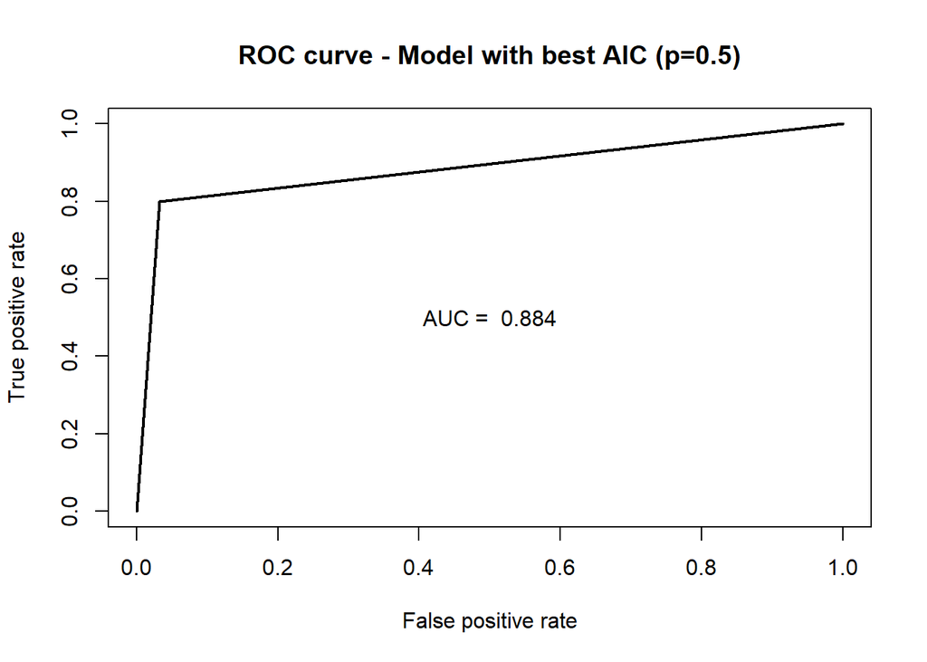

```r
best_aic_prediction <- prediction(logistic_pred_bestAIC, test.data$Diabetic)

roc_curve_best_Aic <- performance(best_aic_prediction, measure="tpr", x.measure = "fpr" )

auc <- performance(best_aic_prediction, measure="auc")

auc <- auc@y.values[[1]]

auc <- round(auc, 3)

plot(roc_curve_best_Aic, main="ROC curve - Model with best AIC (p=0.5)", lwd=2)

full_auc = paste("AUC = ", auc)

text(0.5, 0.5, full_auc)
```

```r
# (Testing) error rate among diabetic subjects with p=0.5

table(logistic_pred_bestAIC, test.data$Diabetic)
```

```
##
## logistic_pred_bestAIC   0   1
##                     0 119  11
##                     1   4  44
```

```r
FN = table(logistic_pred_bestAIC, test.data$Diabetic)[1,2]
TP = table(logistic_pred_bestAIC, test.data$Diabetic)[2,2]
err_05_bestAIC  = FN/(FN+TP)
err_05_bestAIC  #0.2
```

```
## [1] 0.2
```

```r
#Prediction and confusion matrix for full model (p=0.1)

log_prob <- predict(best.aic, test.data, type = 'response')
logistic_pred_bestAIC_01 <- rep(0, dim(test.data)[1])
logistic_pred_bestAIC_01[log_prob>0.1] <- 1
full_confusion_01 <- confusionMatrix(data=as.factor(logistic_pred_bestAIC_01), reference = as.factor(test.data$Diabetic), positive = '1')
full_confusion_01
```

```
## Confusion Matrix and Statistics
##
##           Reference
## Prediction  0  1
##          0 93  2
##          1 30 53
##
##                Accuracy : 0.8202
##                  95% CI : (0.7558, 0.8737)
##     No Information Rate : 0.691
##     P-Value [Acc > NIR] : 6.676e-05
##
##                   Kappa : 0.6309
##
##  Mcnemar's Test P-Value : 1.815e-06
##
##             Sensitivity : 0.9636
##             Specificity : 0.7561
##          Pos Pred Value : 0.6386
##          Neg Pred Value : 0.9789
##              Prevalence : 0.3090
##          Detection Rate : 0.2978
##    Detection Prevalence : 0.4663
##       Balanced Accuracy : 0.8599
##
##        'Positive' Class : 1
##
```

```r
# (Testing) error rate among diabetic subjects with p=0.1

table(logistic_pred_bestAIC_01, test.data$Diabetic)
```

```
##
## logistic_pred_bestAIC_01  0  1
##                        0 93  2
##                        1 30 53
```

```r
FN = table(logistic_pred_bestAIC_01, test.data$Diabetic)[1,2]
TP = table(logistic_pred_bestAIC_01, test.data$Diabetic)[2,2]
err_01_bestAIC = FN/(FN+TP)
err_01_bestAIC #0.03636364
```

```
## [1] 0.03636364
```

Here, we plot the ROC curve of the model with best perfomance in terms of sensitivity.

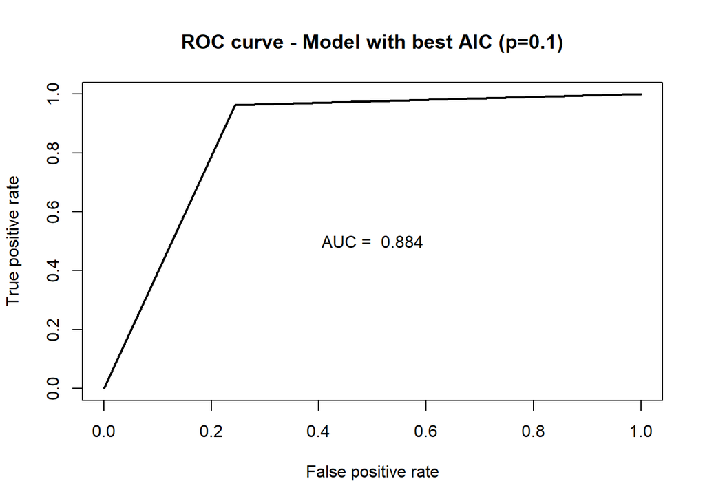

```r
best_aic_prediction_01 <- prediction(logistic_pred_bestAIC_01, test.data$Diabetic)

roc_curve_best_Aic_01 <- performance(best_aic_prediction_01, measure="tpr", x.measure = "fpr" )

auc <- performance(best_aic_prediction_01, measure="auc")

auc <- auc@y.values[[1]]

auc <- round(auc, 3)

plot(roc_curve_best_Aic_01, main="ROC curve - Model with best AIC (p=0.1)", lwd=2)

auc_best_bestAIC = paste("AUC = ", auc)

text(0.5, 0.5, full_auc)
```

### 2.3.3 Comparison of models

In order to check which is our best model, we visually contrast both new models with the full model predictions in order to select the model with best performance.

```r
# Among models with best sensitivity, which has the highest AUC?

auc_best_full > auc_best_bestAIC #TRUE
```

```
## [1] TRUE
```

```r
auc_best_bestAIC > auc_best_VIFmod #FALSE
```

```
## [1] FALSE
```

```r
auc_best_full > auc_best_VIFmod #FALSE
```

```
## [1] FALSE
```

```r
auc_best_VIFmod > auc_best_bestAIC #TRUE
```

```
## [1] TRUE
```

```r
auc_best_VIFmod == auc_best_full #TRUE: the model identified through VIF analysis and the full model
```

```
## [1] TRUE
```

```r
                                 # have the same, and highest, AUC
```

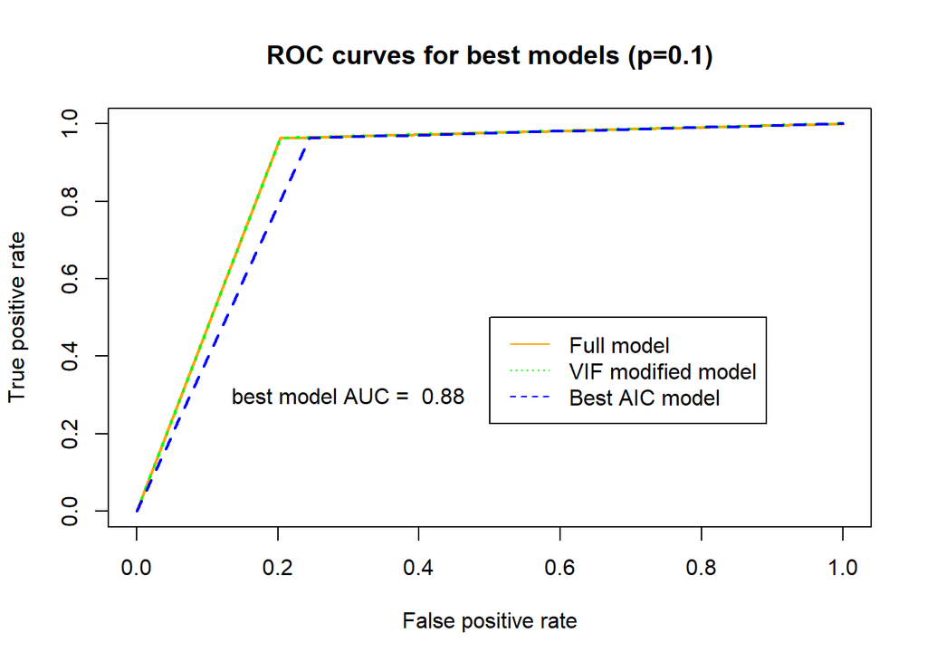

```r
plot(roc_curve_full_01, col='orange', main='ROC curves for best models (p=0.1)', lty=1, lwd=2)

plot(roc_curve_VIF_01, add=TRUE, col='green', lty=3, lwd=2)

plot(roc_curve_best_Aic_01, add=TRUE, col='blue', lty=2, lwd=2)

auc <- performance(VIF_prediction_01, measure="auc")

auc <- auc@y.values[[1]]

auc <- round(auc, 3)

best_auc = paste("best model AUC = ", auc)

text(0.3, 0.3, best_auc)


legend(0.5, 0.5, legend=c("Full model", "VIF modified model", "Best AIC model"),
       col=c("orange", "green", "blue"), lty=c(1,3,2))
```